# Accidental Drug Related Deaths

Team Name:

- Team Opioid Crisis

Contributors: Part 1 and Part 2

- Daniel Cox (saunderscox) - Analyses and visualizations, technical assistance
- Chaipakon Luangprasert (chaipakon197) - Technical assistance, Analyses and visualizations
- Tucker Shaver (tucker4) - Analyses and visualizations, Data cleaning, technical assistance

## Overview

Over the past century, drug abuse in our nation has sky rocketed. What are the trends, and what can we infer from the data? We know there has been a synthetic opioid crisis permeating the United States. Are there any clues or patterns we can gather given drug data from a specific state? Could we isolate an outlier to show us what may be happening in the drug market? With this data, no hard conclusions can be made, but perhaps it will reveal some parallels to recent reports from various news outlets.

## Data

### What is our data?

In this analysis, we will be looking at a report of accidental drug related deaths in Connecticut. We are choosing this set of data, because it contains some of the most recent information on the subject that may reflect a trend in the overall drug market. This data set is not representative of the population of the U.S., because drug popularity varies significantly from region to region. However, a significant change over the course of 6 years may reveal something less obvious.

The data we are using was updated on May 8, 2019 from https://catalog.data.gov/dataset/accidental-drug-related-deaths-january-2012-sept-2015 by the Office of the Chief Medical Examiner.

### How can we see our data?

In our table, we will focus on the date of the accidents involved with each drug and how the amount of cases change from date to date.

```python
import pandas as pd
import matplotlib.pyplot as plt
import numpy as np
import math
```

We had to clean up the date by removing the day and time stamp. There were many people in the table that did not have a specific date, race, or sex so they were removed. We replaced all the 'Y's (which signifies that drug was in their system at death) with a 1 and the other blank slots with a 0. There were many other slots that did not have a blank slot or a 'Y', These slots were replaced accordingly.

```python
pd.set_option('display.max_rows', 5)
data = pd.read_csv("Accidental_Drug_Related_Deaths_2012-2018.csv")

the = list()
for date in data.Date:
    the.append(str(date)[:3] + str(date)[6:10])
data.Date = the
data = data[pd.notnull(data['Sex'])].reset_index(drop=True)
data = data[(data['Sex'] != 'Unknown')].reset_index(drop=True)
data = data[pd.notnull(data['Date'])].reset_index(drop=True)
data = data[pd.notnull(data['Race'])].reset_index(drop=True)
data = data.replace('Y', 1)
data = data.replace('N', 0)
data = data.replace('Y POPS', 0)
data = data.replace('Y (PTCH)', 0)
data = data.replace('Y-A', 1)
data.Date = data.Date.astype(str)
data = data.fillna(0)
data = data.drop(2671,axis=0).reset_index(drop=True)
data
```

|  | ID | Date | DateType | Age | Sex | Race | ResidenceCity | ResidenceCounty | ResidenceState | DeathCity | ... | Tramad | Morphine_NotHeroin | Hydromorphone | Other | OpiateNOS | AnyOpioid | MannerofDeath | DeathCityGeo | ResidenceCityGeo | InjuryCityGeo |
| --- | --- | --- | --- | --- | --- | --- | --- | --- | --- | --- | --- | --- | --- | --- | --- | --- | --- | --- | --- | --- | --- |
| 0 | 13-0102 | 03/2013 | DateofDeath | 48.0 | Male | Black | NORWALK | 0 | 0 | NORWALK | ... | 0.0 | 0 | 0.0 | 0 | 0.0 | 0.0 | Accident | Norwalk, CT\n(41.11805, -73.412906) | NORWALK, CT\n(41.11805, -73.412906) | CT\n(41.575155, -72.738288) |
| 1 | 16-0165 | 03/2016 | DateofDeath | 30.0 | Female | White | SANDY HOOK | FAIRFIELD | CT | DANBURY | ... | 0.0 | 0 | 0.0 | 0 | 0.0 | 1.0 | Accident | Danbury, CT\n(41.393666, -73.451539) | SANDY HOOK, CT\n(41.419998, -73.282501) | 0 |
| ... | ... | ... | ... | ... | ... | ... | ... | ... | ... | ... | ... | ... | ... | ... | ... | ... | ... | ... | ... | ... | ... |
| 5085 | 14-0124 | 03/2014 | DateofDeath | 33.0 | Male | White | HARTFORD | 0 | 0 | WINDSOR | ... | 0.0 | 0 | 0.0 | 0 | 0.0 | 0.0 | Accident | WINDSOR, CT\n(41.852781, -72.64379) | HARTFORD, CT\n(41.765775, -72.673356) | CT\n(41.575155, -72.738288) |
| 5086 | 16-0637 | 09/2016 | DateofDeath | 33.0 | Male | White | THOMASTON | LITCHFIELD | CT | WATERBURY | ... | 0.0 | 0 | 0.0 | 0 | 0.0 | 1.0 | Accident | WATERBURY, CT\n(41.554261, -73.043069) | THOMASTON, CT\n(41.674124, -73.073189) | WATERBURY, CT, CT\n(41.554261, -73.043069) |

5087 rows × 41 columns

```python
data = pd.read_csv("Accidental_Drug_Related_Deaths_2012-2018-2.csv")
data['Month'] = [(data.iloc[i].Date[0:2]) for i in range(data.shape[0])]
data['Year'] = [(data.iloc[i].Date[3:7]) for i in range(data.shape[0])]
data.sort_values(by=['Year', 'Month'], inplace=True)
data
```

|  | Date | Age | Sex | Race | COD | Heroin | Cocaine | Fentanyl | FentanylAnalogue | Oxycodone | Ethanol | Benzodiazepine | Methadone | AnyOpioid | Month | Year |
| --- | --- | --- | --- | --- | --- | --- | --- | --- | --- | --- | --- | --- | --- | --- | --- | --- |
| 144 | 01/2012 | 35.0 | Male | White | Heroin Toxicity | 1.0 | 0.0 | 0.0 | 0.0 | 0.0 | 0.0 | 0.0 | 0.0 | 0.0 | 01 | 2012 |
| 516 | 01/2012 | 31.0 | Female | White | Complications of Opiate Toxicity | 0.0 | 0.0 | 0.0 | 0.0 | 0.0 | 0.0 | 0.0 | 0.0 | 0.0 | 01 | 2012 |
| ... | ... | ... | ... | ... | ... | ... | ... | ... | ... | ... | ... | ... | ... | ... | ... | ... |
| 4854 | 12/2018 | 44.0 | Male | White | Acute Intoxication From the Combined Effects o... | 0.0 | 1.0 | 1.0 | 0.0 | 0.0 | 1.0 | 0.0 | 0.0 | 1.0 | 12 | 2018 |
| 4948 | 12/2018 | 40.0 | Male | White | Acute Oxycodone and Amphetamine Intoxication. | 0.0 | 0.0 | 0.0 | 0.0 | 1.0 | 0.0 | 0.0 | 0.0 | 1.0 | 12 | 2018 |

5087 rows × 16 columns

### Yearly Basis

When we visualize the accidents on a yearly basis, it becomes clear that the rate of drug related deaths was growing steadily until 2018. Could that mean that some intervention became effective in 2018? Perhaps. We'll have to look further.

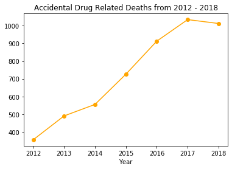

```python
# A quick visualization of the drug related deaths breakout in recent years
g = yearDistribution = data.groupby('Year')
freqs = g.size()
fig, ax = plt.subplots()
ax.plot(freqs.index, freqs, color='orange', linestyle='-', marker='o')
ax.set_title("Accidental Drug Related Deaths from 2012 - 2018")
ax.set_xlabel("Year")
```

### Primary Culprits

Can we conclude that a drug crisis is effectively being handled if the total amount of incidents is going down? Let's examine the primary culprits. As shown, the top two leading causes of accidental deaths stem from the opioids: heroin, made from morphine, a natural substance harvested from poppy seeds, and fentanyl, a synthetic opioid similar to morphine but much more potent and likely to be mixed with either heroin or cocaine.

The following visualization demonstrates this, but it is important to understand that multiple drugs could have accounted for a single death. For example, if both heroin and fentanyl were related to a death, they would be counted once for each drug.

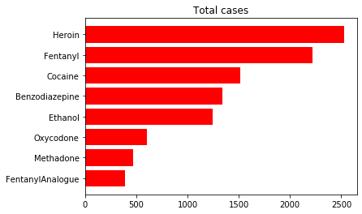

```python
# But who is the culprit? We can see the heroin has been the leader of these cases
drugCount = []
for i in range(5,13):
    drugCount.append(data.iloc[:,i].sum())

drugCount
drugList = [data.columns[i] for i in range(5,13)]
sums = pd.DataFrame({'Cases':drugCount})
sums.index = drugList
sums.sort_values(by='Cases', inplace=True)

fig, ax = plt.subplots()
ax.barh(sums.index, sums.Cases, color='red')
ax.set_title("Total cases")
```

```python
drugs = [[data.iloc[j,i] for i in range(5, 13)] for j in range(0,data.shape[0])]
data['Drugs'] = drugs
```

### Years vs. Drug

Among the top five drugs associated with accidental deaths, four of the drugs were less likely to cause death in 2018 than the previous year, 2017. Could that be because they were used less, or could it link to rapidly rising fentanyl on the black market?

According to an article on MDEdge Psychiatry Richard Franki, "The [U.S. data shows] that total drug overdose deaths were down from 70,699 in 2017 to 67,744 in 2018, a drop of 4.2%, the CDC said." Although the data varies throughout the U.S., Connecticut's mild drop in drug related deaths seems to be a good representative of the overall trend in the U.S. The article also quotes that in 2018, "...the number of patients receiving medication-assisted treatment has risen, distribution of overdose-reversing drugs is up, and nationwide opioid prescriptions are down.”

Source: https://www.mdedge.com/psychiatry/article/204863/addiction-medicine/drug-overdose-deaths-declined-2018

```python
years = ['2012', '2013', '2014', '2015', '2016', '2017', '2018']

drugUseYears = []
for drug in range (5, 14):
    drugUse = []
    for year in years:
        drugUse.append(sum([data.iloc[i,drug] for i in range(0,data.shape[0]) if data.iloc[i,15]==year]))
    drugUseYears.append(drugUse)

drugUseYears

drugYears = pd.DataFrame({'Year':years, 'Heroin':drugUseYears[0], 'Fentanyl':drugUseYears[2], 'Cocaine':drugUseYears[1], 'Benzodiazepine':drugUseYears[6], 'Ethanol':drugUseYears[5]})
drugYears
```

|  | Year | Heroin | Fentanyl | Cocaine | Benzodiazepine | Ethanol |
| --- | --- | --- | --- | --- | --- | --- |
| 0 | 2012 | 174.0 | 13.0 | 105.0 | 49.0 | 61.0 |
| 1 | 2013 | 257.0 | 36.0 | 147.0 | 78.0 | 83.0 |
| ... | ... | ... | ... | ... | ... | ... |
| 5 | 2017 | 473.0 | 674.0 | 345.0 | 329.0 | 290.0 |
| 6 | 2018 | 388.0 | 757.0 | 342.0 | 265.0 | 254.0 |

7 rows × 6 columns

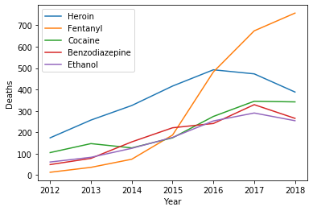

```python
# But on a year by year scale, we can see the Fentanyl has
# been abused on an extreme case since 2016
plt.plot('Year', 'Heroin', data=drugYears)
plt.plot('Year', 'Fentanyl', data=drugYears)
plt.plot('Year', 'Cocaine', data=drugYears)
plt.plot('Year', 'Benzodiazepine', data=drugYears)
plt.plot('Year', 'Ethanol', data=drugYears)
plt.legend()
plt.xlabel("Year")
plt.ylabel("Deaths")
```

# Narrowing Our Focus on Fentanyl

Here are some of the things we learned from our initial analysis.

- The number of deaths associated with drugs sorted from most to least show that the opioids are the leading causes of accidental deaths:
  - Heroin
  - Fentanyl
  - Cocaine
  - Benzadiazepine
  - Ethanol
  - Oxycodone
  - Methadone
  - FentanylAnalogue.

However, as you can see from the above graph, Fentanyl is the only drug that is rising. So in the next section, we will focus our research more on Fentanyl.

# Fentanyl Related Deaths

We can further investigate the Fentanyl related deaths with other data supplied such as age and sex.

## Deaths Related to Sex

The following visualization shows that both sexes incurred drug related deaths growing until around 2018, where the deaths began to decrease. One interesting point to note is that there was no significant change in growth for females, while there was a drastic change in growth for males starting in 2015.

```
The total number of death is 2223, 1758 being male and 465 being female.
```

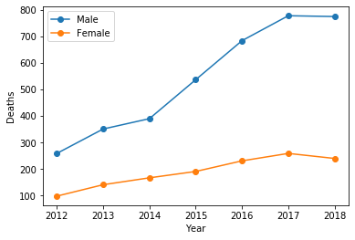

```python
pd.options.display.max_rows = 100
pd.options.display.max_columns = 100
%matplotlib inline

# make a copy of the clean data
dataQ2 = data.copy()
# clean out some of the data
dfQ2 = dataQ2.drop(dataQ2.index[dataQ2.Fentanyl == 0].tolist())

male = len(dfQ2.index[dfQ2.Sex == 'Male'].tolist())
female = len(dfQ2.index[dfQ2.Sex == 'Female'].tolist())
print("The total number of death is "+ str(male+female) + ", " + str(male) + " being male and " + str(female)+ " being female.")
dfQ2F = dataQ2.drop(dataQ2.index[dataQ2.Sex == "Male"].tolist())
dfQ2M = dataQ2.drop(dataQ2.index[dataQ2.Sex == "Female"].tolist())
dfQ2FY = dfQ2F.groupby('Year')
dfQ2MY = dfQ2M.groupby('Year')

freF = dfQ2FY.size()
freM = dfQ2MY.size()

combineDF = pd.DataFrame({'Year':years, 'Male':freM, 'Female':freF})
combineDF
figSex = plt.plot('Year', 'Male', data=combineDF,  marker='o')
plt.plot('Year', 'Female', data=combineDF,  marker='o')
plt.legend()
plt.xlabel("Year")
plt.ylabel("Deaths")
```

## Deaths Related to Sex cont'd

We can say the the U.S. efforts have succeeded in diminishing the growth of Fentanyl related deaths, but we can't neglect that the amount of deaths per year is still high. The following visualization will help us better understand that there are still a great amount of victims to drugs even in the most recent years.

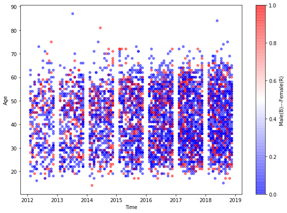

```python
the = list()
for s in data.Sex:
    if s == 'Male':
        the.append(0)
    else:
        the.append(1)
data['Male(B)---Female(R)'] = the
y = data.Year.astype(int)
m = data.Month.astype(int)
data['Time'] = y + m * 10**-2 * 7 + .04
p = data.plot.scatter(x='Time',y='Age', c='Male(B)---Female(R)', colormap= plt.cm.bwr, figsize=(10,7), alpha=0.5, sharex=False)
p
```

## Deaths Related to Age

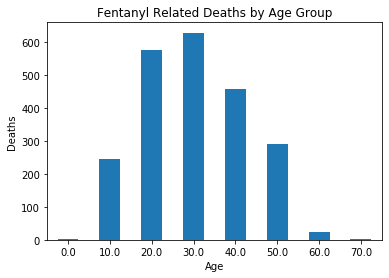

```python
dfQ2Age = dfQ2.copy()
dfQ2Age.Age = round(dfQ2Age.Age, -1) - 10
dfA = dfQ2Age.groupby('Age')
dfAA = dfA.size()
axA = dfAA.plot(kind='bar', rot=0)
axA.set_title("Fentanyl Related Deaths by Age Group")
plt.ylabel("Deaths")
```

# Fentanyl Related Deaths by Month

We further examine Fentanyl related deaths in more detail by viewing the trend by each month. We can't necessarily say we have a success when the death count decreases by a single month, because the change in death count varies tremendously from month to month. What we can hypothesize is that there may be an interval associated with death spikes. The spike isn't a constant interval, but we can estimate that about every 2 to 5 months there is another dramatic increase in the number of deaths.

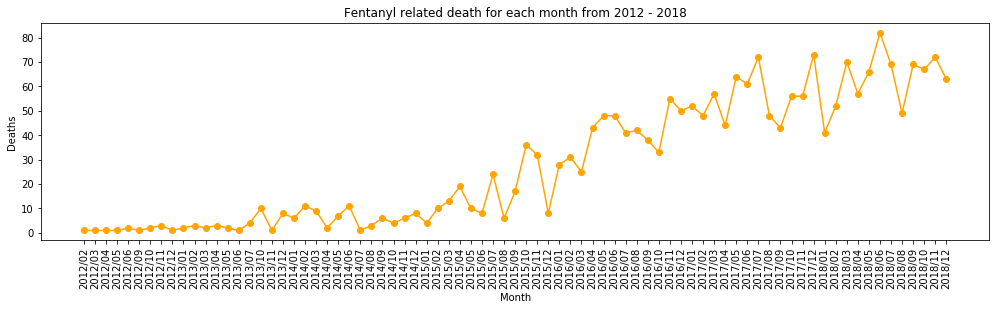

```python
dfQ2['YearMonth'] = data.Year+"/"+data.Month
dfQ2
# A quick visualization of the drug related deaths breakout in recent years
g2 = dfQ2.groupby('YearMonth')
freqs2 = g2.size()
freqs2
fig, ax5 = plt.subplots(figsize=(17,4))
ax5.plot(freqs2.index, freqs2, color='orange', linestyle='-', marker='o')
ax5.set_title("Fentanyl related death for each month from 2012 - 2018")
ax5.set_xlabel("Month")
ax5.set_xticklabels(freqs2.index, rotation=90);
plt.ylabel("Deaths")
```

# Fentanyl Related Deaths by Month cont'd

The following visualization helps us see that the change in death count varies greatly from month to month, but there is a high chance that every 2 to 5 months, an increase in deaths reverts to a decrease or vice versa.

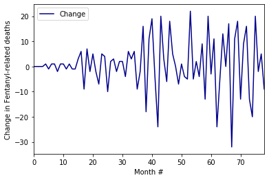

```python
fent = pd.DataFrame(data=freqs2)
change = [0]
for i in range(1, fent.shape[0]):
    change.append(fent[0][i]-fent[0][i-1])
fent['Change'] = change
fent['Month'] = [i for i in range(0, fent.shape[0])]
ax1 = fent.plot(x='Month', y='Change', c='DarkBlue')
plt.xlabel("Month #")
plt.ylabel("Change in Fentanyl-related deaths")
```

```python
fent = fent.sort_values(by='Change', ascending=False)
fent
```

| YearMonth | 0 | Change | Month |
| --- | --- | --- | --- |
| 2016/11 | 55 | 22 | 53 |
| 2018/09 | 69 | 20 | 75 |
| 2017/05 | 64 | 20 | 59 |
| 2016/01 | 28 | 20 | 43 |
| 2015/10 | 36 | 19 | 40 |
| 2016/04 | 43 | 18 | 46 |
| 2018/03 | 70 | 18 | 69 |
| 2017/12 | 73 | 17 | 66 |
| 2018/06 | 82 | 16 | 72 |
| 2015/07 | 24 | 16 | 37 |
| 2017/10 | 56 | 13 | 64 |
| 2015/09 | 17 | 11 | 39 |
| 2018/02 | 52 | 11 | 68 |
| 2017/07 | 72 | 11 | 61 |
| 2018/05 | 66 | 9 | 71 |
| 2017/03 | 57 | 9 | 57 |
| 2013/12 | 8 | 7 | 18 |
| 2013/10 | 10 | 6 | 16 |
| 2015/04 | 19 | 6 | 34 |
| 2015/02 | 10 | 6 | 32 |
| 2018/11 | 72 | 5 | 77 |
| 2016/05 | 48 | 5 | 47 |
| 2014/02 | 11 | 5 | 20 |
| 2014/05 | 7 | 5 | 23 |
| 2014/06 | 11 | 4 | 24 |
| 2016/02 | 31 | 3 | 44 |
| 2015/03 | 13 | 3 | 33 |
| 2014/09 | 6 | 3 | 27 |
| 2013/07 | 4 | 3 | 15 |
| 2014/12 | 8 | 2 | 30 |
| 2017/01 | 52 | 2 | 55 |
| 2014/11 | 6 | 2 | 29 |
| 2014/08 | 3 | 2 | 26 |
| 2012/11 | 3 | 1 | 7 |
| 2013/01 | 2 | 1 | 9 |
| 2016/08 | 42 | 1 | 50 |
| 2012/10 | 2 | 1 | 6 |
| 2013/02 | 3 | 1 | 10 |
| 2012/06 | 2 | 1 | 4 |
| 2013/04 | 3 | 1 | 12 |
| 2016/06 | 48 | 0 | 48 |
| 2017/11 | 56 | 0 | 65 |
| 2012/02 | 1 | 0 | 0 |
| 2012/03 | 1 | 0 | 1 |
| 2012/04 | 1 | 0 | 2 |
| 2012/05 | 1 | 0 | 3 |
| 2013/06 | 1 | -1 | 14 |
| 2013/05 | 2 | -1 | 13 |
| 2013/03 | 2 | -1 | 11 |
| 2012/09 | 1 | -1 | 5 |
| 2014/01 | 6 | -2 | 19 |
| 2012/12 | 1 | -2 | 8 |
| 2014/03 | 9 | -2 | 21 |
| 2018/10 | 67 | -2 | 76 |
| 2015/06 | 8 | -2 | 36 |
| 2014/10 | 4 | -2 | 28 |
| 2017/06 | 61 | -3 | 60 |
| 2015/01 | 4 | -4 | 31 |
| 2017/02 | 48 | -4 | 56 |
| 2016/09 | 38 | -4 | 51 |
| 2015/11 | 32 | -4 | 41 |
| 2016/12 | 50 | -5 | 54 |
| 2016/10 | 33 | -5 | 52 |
| 2017/09 | 43 | -5 | 63 |
| 2016/03 | 25 | -6 | 45 |
| 2014/04 | 2 | -7 | 22 |
| 2016/07 | 41 | -7 | 49 |
| 2018/12 | 63 | -9 | 78 |
| 2013/11 | 1 | -9 | 17 |
| 2015/05 | 10 | -9 | 35 |
| 2014/07 | 1 | -10 | 25 |
| 2018/04 | 57 | -13 | 70 |
| 2017/04 | 44 | -13 | 58 |
| 2018/07 | 69 | -13 | 73 |
| 2015/08 | 6 | -18 | 38 |
| 2018/08 | 49 | -20 | 74 |
| 2017/08 | 48 | -24 | 62 |
| 2015/12 | 8 | -24 | 42 |
| 2018/01 | 41 | -32 | 67 |

## Conclusion & Questions

As we've analyzed this data, we can see that Fentanyl abuse is being addressed, but shows no sure trend of a steady decline. One interesting trend we saw in the data was the interval of increase and decrease of deaths varying among a few months at a time. We've speculated that the peaks and valleys of deaths in certain months may be related to a way the drug market functions. We could also speculate that government's promotion of medication-assisted treatment are released on some interval. It seems that the growth of accidental drug related deaths has leveled off across the board, but we'll have to analyze the future year's report to get a sense of how effective the resolution of the drug crisis will be.